# Research Question 1

- Show All Code
- Hide All Code
- View Source

Do sites differ in objectively measured personal light exposure? If so, does an individual’s behaviour and micro-environment have a stronger effect than site?

Author

Johannes Zauner

## Preface

This document contains the analysis for Research Question 1, as defined in the [preregistration](https://aspredicted.org/te3zw2.pdf).

> **Research Question 1**:  
> Do sites differ in objectively measured personal light exposure? If so, does an individual’s behaviour and micro-environment have a stronger effect than site?

> *H1*: There is a significant difference in personal light-exposure metrics across sites, even after accounting for latitude and photoperiod.

> *H2*: The variance of personal light exposure patterns (hourly geometric mean of melanopic EDI) by participants within sites is greater than the variance between sites.

## Setup

In this section, we load in the preprocessed and prepared data, site data, and load required packages.

**Code cell - Setup**

```r
library(tidyverse)
library(melidosData)
library(LightLogR)
library(mgcv)
library(lme4)
library(performance)
library(cowplot)
library(ggridges)
library(broom)
library(itsadug)
library(gratia)
library(patchwork)
library(rlang)
library(broom.mixed)
library(gt)
library(performance)
library(glmmTMB)
library(gghighlight)
library(gtsummary)
source("scripts/fitting.R")
source("scripts/summaries.R")
source("scripts/H1_specific.R")
```

**Code cell - Load data**

```r
load("data/metrics_glasses.RData")
metrics <- metrics_glasses
H1 <- "Hypothesis: There is a significant difference in personal light-exposure metrics across sites, even after accounting for latitude and photoperiod."
H2 <- "Hypothesis: The variance of personal light exposure patterns (hourly geometric mean of melanopic EDI) by participants within sites is greater than the variance between sites."
sig.level <- 0.05

#for chest:
# load("data/metrics_chest.RData")
# metrics <- metrics_chest
# melidos_cities <- melidos_cities[names(melidos_cities)!="MPI"]
```

## Hypothesis 1

### Details

Hypothesis 1 states:

> There is a significant difference in personal light-exposure metrics across sites, even after accounting for latitude and photoperiod.

*Type of model:* LMM

*Base formula:* $\text{Metric} \sim \text{Site} + \text{Photoperiod} + (1|\text{Site}:\text{Participant})$

*Additional notes:* - For dynamics-based metrics LM without Participant random effect. - Because latitude and site are each individual values per site (i.e., each site has its unique latitude), they have to be modelled separately and will be compared via AIC.

*False-discovery-rate correction:* 17 (number of metrics that are compared)

### Preparation

**Code cell - Model setup based on distribution**

```r
model_tbl <- tibble::tribble(
    ~name, ~engine, ~ response, ~family,
    "interdaily_stability", "lm", "qlogis(metric)", gaussian(),
    "intradaily_variability", "lm", "metric", gaussian(),
    "Mean", "lmer", "log_zero_inflated(metric)", gaussian(),
    "dose", "lmer", "log_zero_inflated(metric)", gaussian(),
    "MDER", "lmer", "metric", gaussian(),
    "darkest_10h_mean", "lmer", "log_zero_inflated(metric)", gaussian(),
    "brightest_10h_mean", "lmer", "log_zero_inflated(metric)", gaussian(),
    "duration_above_1000", "glmmTMB", "metric", tweedie(link = "log"),
    "duration_above_250", "lmer", NA, gaussian(),
    "duration_below_10", "lmer", NA, gaussian(),
    "duration_below_1", "lmer", NA, gaussian(),
    "duration_above_250_wake", "glmmTMB", "metric", tweedie(link = "log"),
    "duration_below_10_pre-sleep", "glmmTMB", "metric", tweedie(link = "log"),
    "duration_below_1_sleep", "glmmTMB", "metric", tweedie(link = "log"),
    "period_above_250", "lmer", "log_zero_inflated(metric)", gaussian(),
    "brightest_10h_midpoint", "lmer", "metric", gaussian(),
    "brightest_10h_onset", "lmer", NA, gaussian(),
    "brightest_10h_offset", "lmer", NA, gaussian(),
    "darkest_10h_midpoint", "lmer", "metric", gaussian(),
    "darkest_10h_onset", "lmer", NA, gaussian(),
    "darkest_10h_offset", "lmer", NA, gaussian(),
    "mean_timing_above_250", "lmer", "metric", gaussian(),
    "first_timing_above_250", "lmer", "metric", gaussian(),
    "last_timing_above_250", "lmer", "metric", gaussian()
  )
```

**Code cell - Formula setup for inference**

```r
metrics <-
  metrics |>
  mutate(H1_1 = case_when(type == "participant" ~
                                  "~ site + photoperiod",
                                type == "participant-day" ~
                                  "~ site + photoperiod + (1| site:Id)"),
         H1_0 = case_when(type == "participant" ~
                                   "~ photoperiod",
                                 type == "participant-day" ~
                                  "~ photoperiod + (1| site:Id)"),
         H1_lat = case_when(type == "participant" ~
                                   "~ lat + photoperiod",
                                 type == "participant-day" ~
                                  "~ lat + photoperiod + (1|site:Id)"),
         H1_phot = case_when(type == "participant" ~
                                   "~ site",
                                 type == "participant-day" ~
                                  "~ site + (1|site:Id)"),
         H1_rand = case_when(type == "participant" ~
                                   NA,
                                 type == "participant-day" ~
                                  "~ photoperiod + (1|site/Id)")
         ) |>
  left_join(model_tbl, by = "name")

H1_formulas <-  names(metrics) |> subset(grepl("H1_", names(metrics)))

metrics <-
  metrics |> relocate(all_of(H1_formulas), .after = family)
H1_fdr_n <- metrics |> filter(!is.na(response)) |> nrow()
```

Hypothesis 1: metric model specifications

Hypothesis: There is a significant difference in personal light-exposure metrics across sites, even after accounting for latitude and photoperiod.

|  | Name | Type | Engine | Response | Family | H1 1<sup>1</sup> | H1 0<sup>1</sup> | H1 lat<sup>2</sup> | H1 phot<sup>2</sup> | H1 rand<sup>2</sup> |
| --- | --- | --- | --- | --- | --- | --- | --- | --- | --- | --- |
| duration |  |  |  |  |  |  |  |  |  |  |
| 1 | Duration above 1000 | participant-day | glmmTMB | metric | tweedie | ~ site + photoperiod + (1\| site:Id) | ~ photoperiod + (1\| site:Id) | ~ lat + photoperiod + (1\|site:Id) | ~ site + (1\|site:Id) | ~ photoperiod + (1\|site/Id) |
| 2 | Duration above 250 wake | participant-day | glmmTMB | metric | tweedie | ~ site + photoperiod + (1\| site:Id) | ~ photoperiod + (1\| site:Id) | ~ lat + photoperiod + (1\|site:Id) | ~ site + (1\|site:Id) | ~ photoperiod + (1\|site/Id) |
| 3 | Duration below 10 pre-Sleep | participant-day | glmmTMB | metric | tweedie | ~ site + photoperiod + (1\| site:Id) | ~ photoperiod + (1\| site:Id) | ~ lat + photoperiod + (1\|site:Id) | ~ site + (1\|site:Id) | ~ photoperiod + (1\|site/Id) |
| 4 | Duration below 1 sleep | participant-day | glmmTMB | metric | tweedie | ~ site + photoperiod + (1\| site:Id) | ~ photoperiod + (1\| site:Id) | ~ lat + photoperiod + (1\|site:Id) | ~ site + (1\|site:Id) | ~ photoperiod + (1\|site/Id) |
| 5 | Period above 250 | participant-day | lmer | log_zero_inflated(metric) | gaussian | ~ site + photoperiod + (1\| site:Id) | ~ photoperiod + (1\| site:Id) | ~ lat + photoperiod + (1\|site:Id) | ~ site + (1\|site:Id) | ~ photoperiod + (1\|site/Id) |
| dynamics |  |  |  |  |  |  |  |  |  |  |
| 6 | Interdaily stability | participant | lm | qlogis(metric) | gaussian | ~ site + photoperiod | ~ photoperiod | ~ lat + photoperiod | ~ site |  |
| 7 | Intradaily variability | participant | lm | metric | gaussian | ~ site + photoperiod | ~ photoperiod | ~ lat + photoperiod | ~ site |  |
| exposure history |  |  |  |  |  |  |  |  |  |  |
| 8 | Dose | participant-day | lmer | log_zero_inflated(metric) | gaussian | ~ site + photoperiod + (1\| site:Id) | ~ photoperiod + (1\| site:Id) | ~ lat + photoperiod + (1\|site:Id) | ~ site + (1\|site:Id) | ~ photoperiod + (1\|site/Id) |
| level |  |  |  |  |  |  |  |  |  |  |
| 9 | Mean | participant-day | lmer | log_zero_inflated(metric) | gaussian | ~ site + photoperiod + (1\| site:Id) | ~ photoperiod + (1\| site:Id) | ~ lat + photoperiod + (1\|site:Id) | ~ site + (1\|site:Id) | ~ photoperiod + (1\|site/Id) |
| 10 | Brightest 10h mean | participant-day | lmer | log_zero_inflated(metric) | gaussian | ~ site + photoperiod + (1\| site:Id) | ~ photoperiod + (1\| site:Id) | ~ lat + photoperiod + (1\|site:Id) | ~ site + (1\|site:Id) | ~ photoperiod + (1\|site/Id) |
| 11 | Darkest 10h mean | participant-day | lmer | log_zero_inflated(metric) | gaussian | ~ site + photoperiod + (1\| site:Id) | ~ photoperiod + (1\| site:Id) | ~ lat + photoperiod + (1\|site:Id) | ~ site + (1\|site:Id) | ~ photoperiod + (1\|site/Id) |
| spectrum |  |  |  |  |  |  |  |  |  |  |
| 12 | MDER | participant-day | lmer | metric | gaussian | ~ site + photoperiod + (1\| site:Id) | ~ photoperiod + (1\| site:Id) | ~ lat + photoperiod + (1\|site:Id) | ~ site + (1\|site:Id) | ~ photoperiod + (1\|site/Id) |
| timing |  |  |  |  |  |  |  |  |  |  |
| 13 | Brightest 10h midpoint | participant-day | lmer | metric | gaussian | ~ site + photoperiod + (1\| site:Id) | ~ photoperiod + (1\| site:Id) | ~ lat + photoperiod + (1\|site:Id) | ~ site + (1\|site:Id) | ~ photoperiod + (1\|site/Id) |
| 14 | Darkest 10h midpoint | participant-day | lmer | metric | gaussian | ~ site + photoperiod + (1\| site:Id) | ~ photoperiod + (1\| site:Id) | ~ lat + photoperiod + (1\|site:Id) | ~ site + (1\|site:Id) | ~ photoperiod + (1\|site/Id) |
| 15 | First timing above 250 | participant-day | lmer | metric | gaussian | ~ site + photoperiod + (1\| site:Id) | ~ photoperiod + (1\| site:Id) | ~ lat + photoperiod + (1\|site:Id) | ~ site + (1\|site:Id) | ~ photoperiod + (1\|site/Id) |
| 16 | Last timing above 250 | participant-day | lmer | metric | gaussian | ~ site + photoperiod + (1\| site:Id) | ~ photoperiod + (1\| site:Id) | ~ lat + photoperiod + (1\|site:Id) | ~ site + (1\|site:Id) | ~ photoperiod + (1\|site/Id) |
| 17 | Mean timing above 250 | participant-day | lmer | metric | gaussian | ~ site + photoperiod + (1\| site:Id) | ~ photoperiod + (1\| site:Id) | ~ lat + photoperiod + (1\|site:Id) | ~ site + (1\|site:Id) | ~ photoperiod + (1\|site/Id) |

Confirmatory analysis will use a p-value correction through the false-discovery rate for n=17 comparisons  
<sup>1</sup> These are the models used for the confirmatory analysis. Each H1 1 and H1 0 pair are compaired with likelihood-ratio tests to determine whether site is meaningful  
<sup>2</sup> These models will be checked via AIC against H1 1 to see whether there is indeed a site difference beyond the specific difference in the model. Also, this model is compared against the H1 0 model

**Code cell - Formula creation**

```r
metrics <-
  metrics |>
  mutate(across(all_of(H1_formulas),
                \(x) map2(x, response, \(y,z) make_formula(z, y))
                )
         )
```

**Code cell - Offset zero-values in mixed gamma models**

```r
 metrics <-
  metrics |>
  mutate(data = map2(data, engine, \(data, engine) {
    if(engine == "glmer") {
      data |> mutate(metric = metric + 0.1)
    } else data
  }))
```

### Analysis

#### Fit models

**Code cell - Model fit**

```r
metrics <-
  metrics |>
  mutate(
    across(all_of(H1_formulas),
           \(x) pmap(list(data, x, engine, family), fit_model),
           .names = "{.col}_model")
    )
```

#### Main model diagnostics

**Code cell - Create diagnostic plots for main model**

```r
metrics <-
  metrics |>
  mutate(
    across(all_of(paste0(H1_formulas[1], "_model")),
           \(x) map(x, diagnostics),
           .names = "{str_remove(.col, '_model')}_diagnostics")
    )
```

Model diagnostics overall look good to OK. Anomalies are found but deemed non-critical. Alternative error families, like the `Tweedie` distribution have been used as well. For `Tweedie` models, the homogeneity of variance does not show in the plots (duration metrics), but was checked interactively.

**Interdaily stability**

[figure not shown]

**Intradaily variability**

[figure not shown]

**Mean**

[figure not shown]

**Brightest 10h mean**

[figure not shown]

**Brightest 10h midpoint**

[figure not shown]

**Darkest 10h mean**

[figure not shown]

**Darkest 10h midpoint**

[figure not shown]

**Duration above 1000**

[figure not shown]

**Period above 250**

[figure not shown]

**Mean timing above 250**

[figure not shown]

**First timing above 250**

[figure not shown]

**Last timing above 250**

[figure not shown]

**Dose**

[figure not shown]

**Mder**

[figure not shown]

**Duration below 10 pre-Sleep**

[figure not shown]

**Duration below 1 sleep**

[figure not shown]

**Duration above 250 wake**

[figure not shown]

### Model comparisons

**Code cell - Model comparisons**

```r
metrics <-
  metrics |>
  mutate(
    H1_1_comp = map2(H1_0_model, H1_1_model, model_anova),
    H1_1_p = map2(H1_1_comp, engine, model_comp_p, n = H1_fdr_n) |> list_c(),
    H1_1_sig = H1_1_p <= sig.level,

    H1_lat_comp = map2(H1_0_model, H1_lat_model, model_anova),
    H1_lat_p = map2(H1_lat_comp, engine, model_comp_p, n = H1_fdr_n) |> list_c(),
    H1_lat_sig = H1_lat_p <= sig.level,

    H1_phot_comp = map2(H1_phot_model, H1_1_model, model_anova),
    H1_phot_p = map2(H1_phot_comp, engine, model_comp_p, n = H1_fdr_n) |> list_c(),
    H1_phot_sig = H1_phot_p <= sig.level,

    H1_rand_comp = map2(H1_0_model, H1_rand_model, model_anova),
    H1_rand_p = map2(H1_rand_comp, engine, model_comp_p, n = H1_fdr_n) |> list_c(),
    H1_rand_sig = H1_rand_p <= sig.level,

    AICs = pmap(list(H1_0_model, H1_1_model, H1_phot_model, H1_lat_model,
                     H1_rand_model), model_AIC),

    summary = pmap(list(H1_1_sig, H1_0_model, H1_1_model), model_summary),
    summary_lat = pmap(list(H1_lat_sig, H1_0_model, H1_lat_model), model_summary),
    summary_rand = pmap(list(H1_rand_sig, H1_0_model, H1_rand_model),
                        model_summary),

    table = pmap(list(name, H1_1_p, summary, metric_type,
                           response, family), model_table),
    table_lat = pmap(list(name, H1_lat_p, summary_lat, metric_type,
                           response, family), model_table),
    table_lat = map(table_lat, \(x) if(is.null(x)) return() else x |>
                  mutate(across(any_of("lat"), \(x) x*10))),
    table = map2(table, H1_phot_sig, \(x,y) if(is.null(x)) return() else x |>
                  mutate(dAIC_photoperiod = ifelse(y, 0, -3))),
    table_rand = pmap(list(name, H1_rand_p, summary_rand, metric_type,
                           response, family),model_table),
    table = pmap(list(table, table_lat, AICs, "lat", "H1_1", "H1_lat"),
                 H1_combining_tables),
    table = pmap(list(table, table_rand, AICs, "SD Site", "H1_1", "H1_rand"),
                 H1_combining_tables),
    )
```

### R^2

**Code cell - calculate R^2**

```r
R2_table <-
  metrics |>
  filter_out(is.na(response)) |>
  mutate(
    name = name,
    metric_type = metric_type,
    H1_1_r2 = pmap(list(H1_1_model, data, family), r2_helper),
    H1_0_r2 = pmap(list(H1_0_model, data, family), r2_helper),
    H1_phot_r2 = pmap(list(H1_phot_model, data, family), r2_helper),
    H1_lat_r2 = pmap(list(H1_lat_model, data, family), r2_helper),
    H1_phot_sig = H1_phot_sig,
    H1_lat_sig = H1_lat_sig,
    H1_1_sig = H1_1_sig,
    .keep = "none"
  )
```

**Code cell - choose relevant R^2**

```r
R2_table <-
  R2_table |>
  rowwise() |>
  mutate(
    name = name,
    metric_type = metric_type,
    marginal_r2 = ifelse(H1_1_sig, H1_1_r2$R2_marginal, H1_0_r2$R2_marginal),
    conditional_r2 = ifelse(H1_1_sig, H1_0_r2$R2_conditional, H1_0_r2$R2_conditional),
    site_r2 = ifelse(H1_1_sig, H1_1_r2$R2_marginal - H1_0_r2$R2_marginal, NA),
    phot_r2 = ifelse(H1_phot_sig, H1_1_r2$R2_marginal - H1_phot_r2$R2_marginal, NA),
    rand_r2 = ifelse(H1_1_sig, H1_1_r2$R2_conditional - H1_1_r2$R2_marginal, #
                     H1_0_r2$R2_conditional - H1_0_r2$R2_marginal),
    rand_r2 = ifelse(rand_r2 == 0, NA, rand_r2),
    lat_r2 = ifelse(H1_lat_sig, H1_lat_r2$R2_marginal - H1_0_r2$R2_marginal, NA),
    .keep = "none"
  ) |>
  mutate(across(c(marginal_r2, conditional_r2),
                \(x) ifelse(metric_type == "dynamics", NA, x)
                ),
             phot_r2 = ifelse(is.na(site_r2) & !is.na(conditional_r2), marginal_r2, phot_r2)
         )
```

### Results

**Code cell - Table H1**

```r
H1_tab <- H1_table(metrics, H1_fdr_n) |> cols_width(Plot ~ px(200))
H1_tab
gtsave(H1_tab, "tables/H1.png", vwidth = 1700)
save(metrics, file = "data/H1_results.RData")
```

Table 1

Model results for Hypothesis 1

Hypothesis: There is a significant difference in personal light-exposure metrics across sites, even after accounting for latitude and photoperiod.

Coefs are<sup>2</sup>

p-value<sup>3</sup>

Intercept

Site intercept (±coefficients)<sup>1</sup>

Photoperiod<sup>4,5</sup>

SD Participant

SD Residual<sup>6</sup>

Comparative models

Distribution<sup>8</sup>

Borås (SE)

Delft (NL)

Dortmund (DE)

Tübingen (DE)

Munich (DE)

Madrid (ES)

Izmir (TR)

San José (CR)

Kumasi (GH)

Latitude<sup>7,4</sup>

SD Site<sup>7,4</sup>

Duration

Duration above 1000

multiplied

>0.9

5m 43s

—

—

—

—

—

—

—

—

—

1.17

1.84

—

—

—

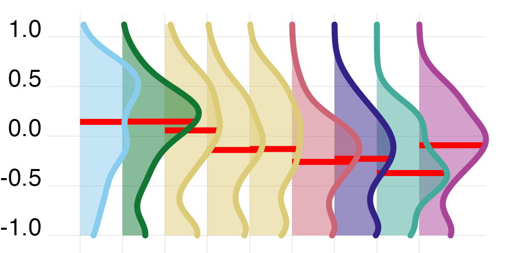

Duration above 250 wake

multiplied

0.062

38m 26s

—

—

—

—

—

—

—

—

—

1.10

1.77

—

—

—

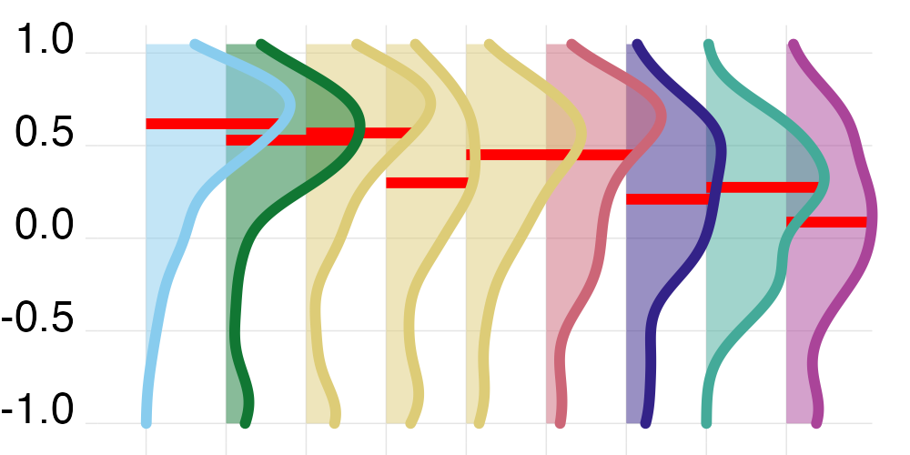

Duration below 10 pre-Sleep

multiplied

>0.9

2h 31m

—

—

—

—

—

—

—

—

—

0.97

1.40

—

—

—

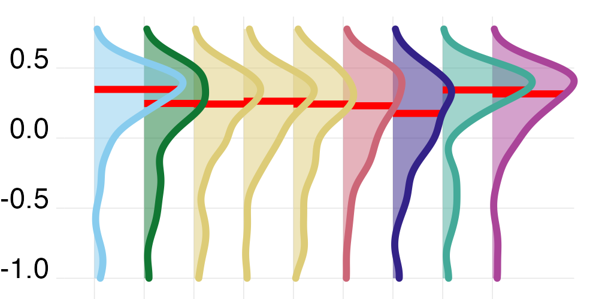

Duration below 1 sleep

multiplied

>0.9

8h 57m

—

—

—

—

—

—

—

—

—

0.98

1.20

—

—

—

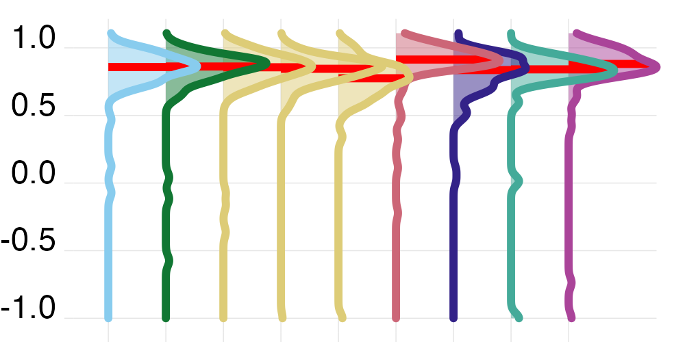

Period above 250

multiplied

>0.9

10m 27s

—

—

—

—

—

—

—

—

—

1.10

1.63

2.12

—

—

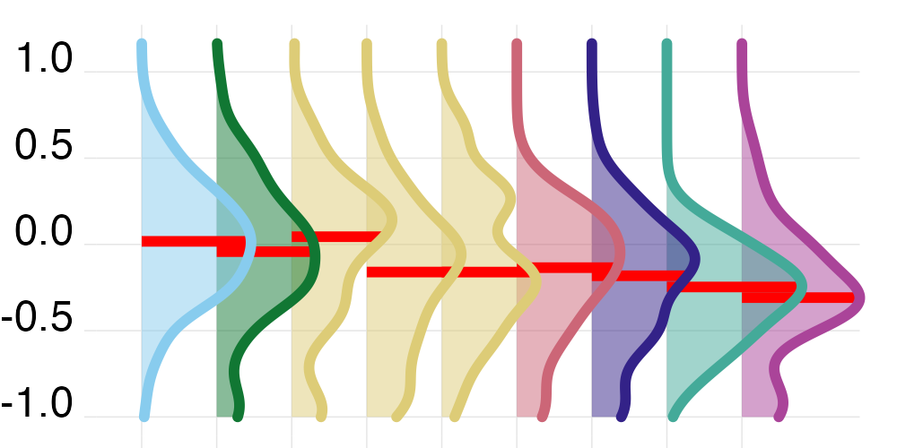

Dynamics<sup>9</sup>

Interdaily stability

logit scale

>0.9

−0.15

—

—

—

—

—

—

—

—

—

−0.05

—

—

—

—

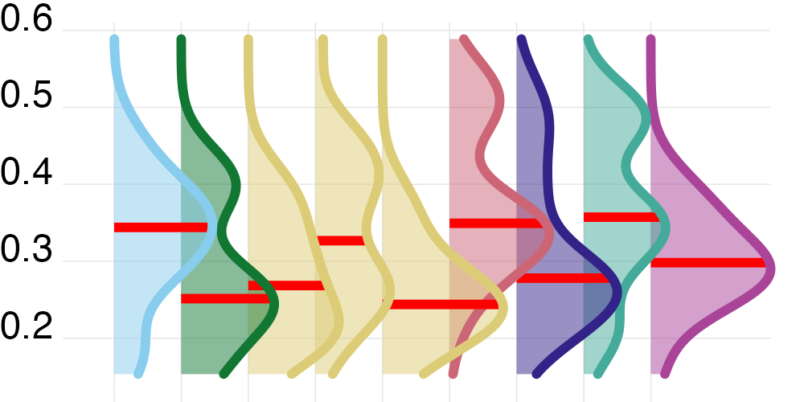

Intradaily variability

additive

>0.9

1.33

—

—

—

—

—

—

—

—

—

0.00

—

—

—

—

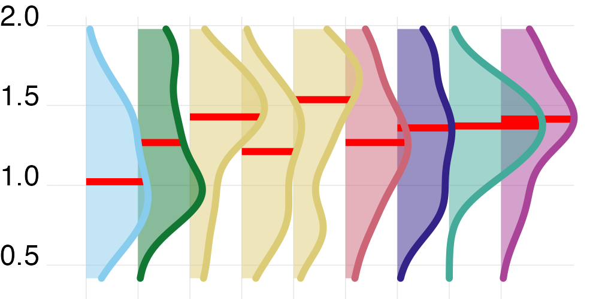

Exposure History

Dose

multiplied

>0.9

356

—

—

—

—

—

—

—

—

—

1.19

2

4

—

—

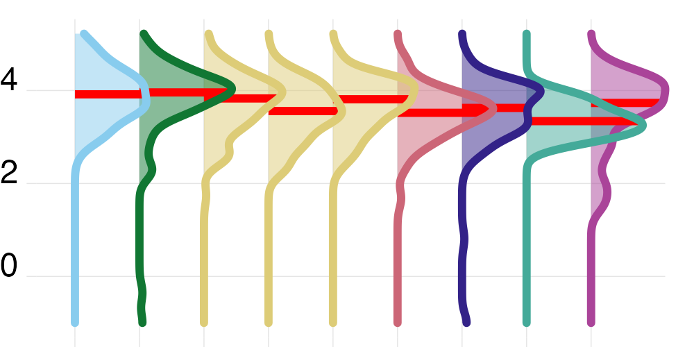

Level

Mean

multiplied

**0.007**

0.41

1.13

1.05

1.00

1.61

1.08

1.13

1.47

1.25

0.54

1.18

1.82

2.02

1.15

1.32

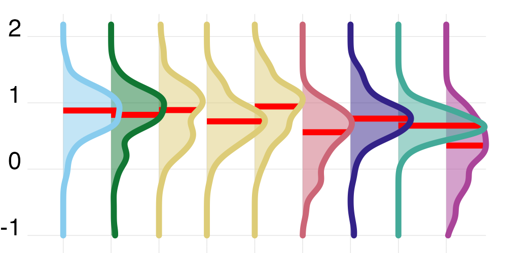

Brightest 10h mean

multiplied

**0.040**

3.94

1.54

1.14

1.00

1.54

0.76

1.50

1.14

1.06

0.43

1.25

2.22

3.17

1.24

—

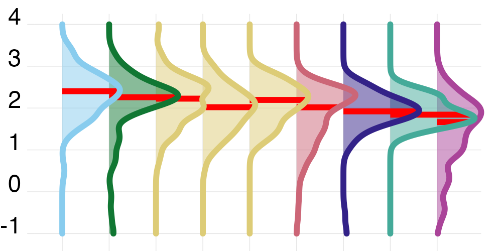

Darkest 10h mean

multiplied

**<0.001**

0.06

0.88

1.03

1.00

1.61

1.60

0.90

1.78

1.72

0.81

1.09

1.63

1.60

—

1.34

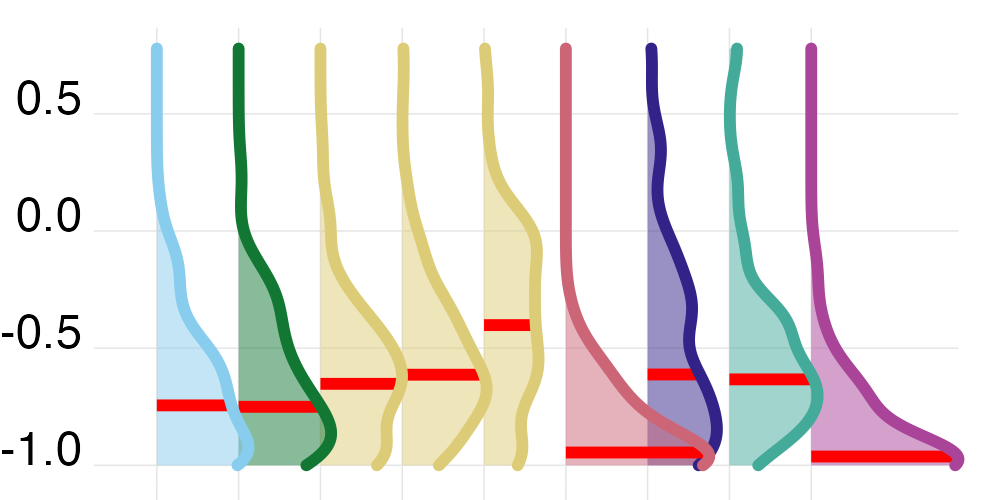

Spectrum

MDER

additive

0.3

0.48

—

—

—

—

—

—

—

—

—

0.02

0.08

0.08

—

—

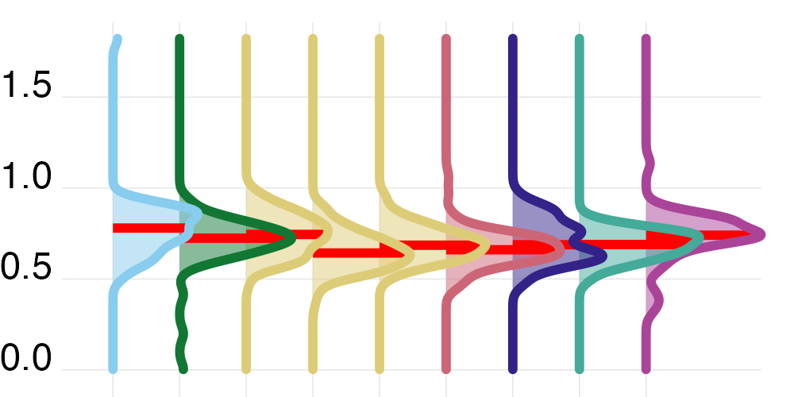

Timing

Brightest 10h midpoint

additive

**0.002**

13.47

−48m 25s

−2m 11s

0s

−2m 48s

26m 22s

25m 47s

21m 12s

−1h 20m

−56m

2m 33s

50m 26s

1h 34m

12m 7s

32m 15s

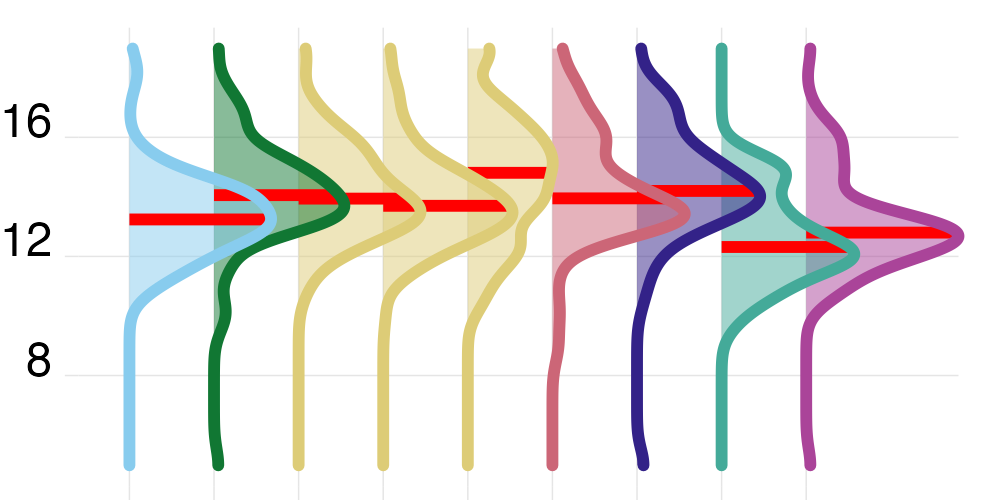

Darkest 10h midpoint

additive

**0.011**

4.87

−32m 51s

−17m 33s

0s

3m 37s

48m 26s

−2m 6s

25m 10s

−44m 26s

−1h 6m

−8m 37s

51m 23s

1h 38m

—

—

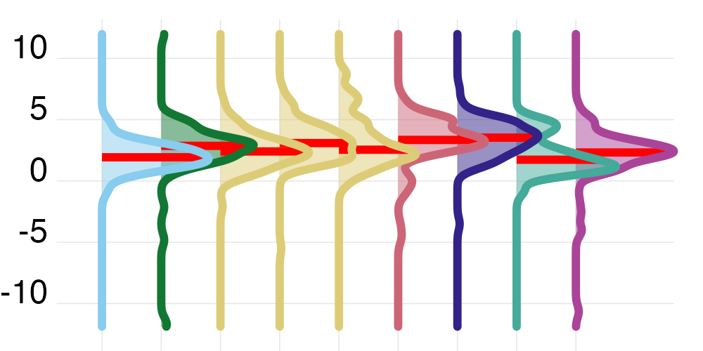

First timing above 250

additive

0.4

11.39

—

—

—

—

—

—

—

—

—

−8m 18s

1h 14m

2h 6m

—

—

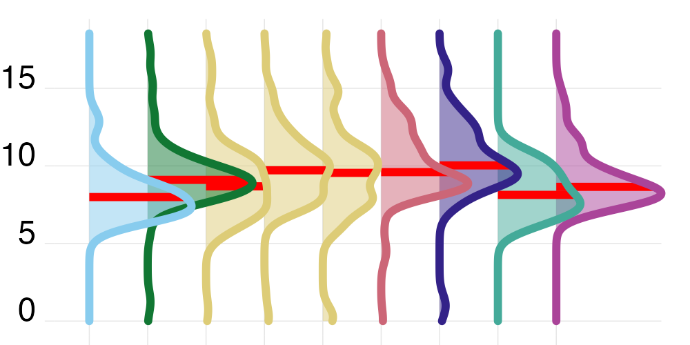

Last timing above 250

additive

**<0.001**

13.18

10m 19s

9m 56s

0s

−16m 38s

33m 58s

1h 13m

44m 12s

−2h 15m

−1h 50m

19m 50s

1h 4m

2h 2m

28m 29s

1h 3m

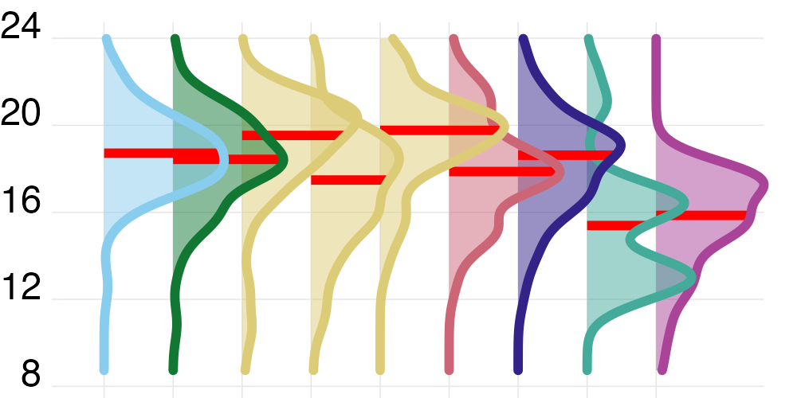

Mean timing above 250

additive

**<0.001**

11.81

−28m 17s

17m 41s

0s

1m 17s

11m 26s

39m 29s

39m 14s

−2h 7m

−1h 18m

7m 27s

33m 11s

1h 34m

21m 17s

52m 9s

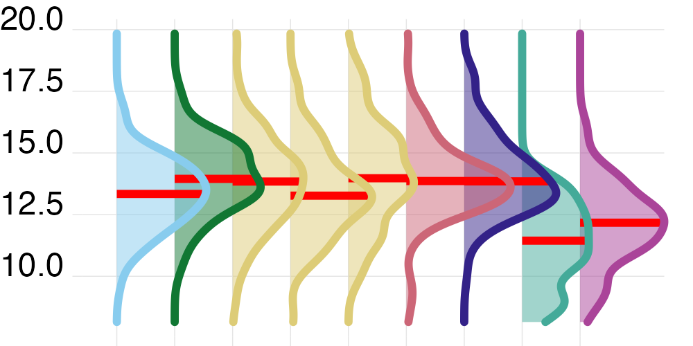

<sup>1</sup> Sites have only entries if the (adjusted) p-value is significant, otherwise the results for the null-model are shown. Entries show the site intercept, with the site-specific coefficient below in brackets (relative to the reference level).

<sup>2</sup> *multiplied*: coefficients are multiplicative. This comes from the fact that the models were calculated on a log scale and backtransformed in the table. The Intercept can be read as linear scale, with coefficients being multiplied with the intercept. *additive*: All values are on the linear scale and no transformation is necessary. *logit scale*: data were modelled on the logit scale. Coefficients can be added to the intercept, but have to be transformed with the logistic function.

<sup>3</sup> p-values are adjusted for multiple comparisons using the false-discovery-rate for n= 17 comparisons

<sup>4</sup> *Photoperiod*: coefficient per 1-hour change in photoperiod. *Latitude*: coefficient per 10° change in latitude. *SD Site*: random effect standard deviation for site.

<sup>5</sup> If the coefficient is greyed out it means it is not significant in a model base minus photoperiod.

<sup>6</sup> Models with a tweedie error distribution do not return a residual standard deviation, as a dispersion parameter is estimated instead during modeling.

<sup>7</sup> These coefficients (*Latitude*) and random effects (*SD Site*) come from two respective separate models that did not contain a fixed effect of site. If the random site or fixed latitude effect is significant, a value is presented. If AIC indicates a significant improvement over the base model (site as fixed effect), it is shown in **bold**. If the base model is significantly stronger, however, values are shown in *grey*.

<sup>8</sup> When coefficients are multiplicative (see column), then the scaling is on a log 10 base, with an offset of +0.1. Red horizontal lines indicate the median of a site.

<sup>9</sup> Dynamics-based metrics are calculated per participant and thus are using linear/generalized models instead of the mixed-model framework

### Interpretation

Table 1 shows a comprehensive overview of the main inference results. When site is significant, site coefficients are with reference to the `BAUA` site.

As way of a high-level summary:

- Timing-based metrics show a significant site-specific effect that is neither dependent on photoperiod, nor latitude
- While level-based metrics show a significant site-specific effect, it can be drawn back to photoperiod and latitude for daytime metrics (but not for nighttime)
- Duration-based metrics are photoperiod-dependent, but not site specific, same as exposure history and spectrum - these metrics are rather more dependent on inter- and intraindividual differences of participants
- In general, interindividual differences highly relevant and trump site specific factors, although usually not as large as intraindividual differences
- None of the above means that individual sites can not be significantly different from the group or another site. But rather that the variance across all nine sites is or is not sufficiently large.

##### Timing and level-based metrics prove site specific

- Both timing and level-based metrics show site specificity, even when controlled for photoperiod
- The `First timing above 250 lx melanopic EDI` (timing) is the only exception, with neither site nor photoperiod-specific influence
- Neither duration, dynamics, exposure history, nor spectrum-based metrics show site specificity

##### Site effects are not random

- With the exception of the `Mean` and the `Darkest 10h mean` (both based on logarithmic scaling), site coefficients are not randomly (normally) distributed, but rather show specific differences, even when controlled for photoperiod
- for `Mean`, a random site factor translates to ± 32% for 1 standard deviation, and for the `Darkest 10h mean` ± 35% for 1 standard deviation

##### Latitude explains daytime levels better than site specifics coefficients

- For the `Mean` and the `Brightest 10h mean`(both based on logarithmic scaling), `latitude` is a better predictor (based on ∆AIC) compared to the `site` (both controlled for photoperiod).
- Per 10 degrees of latitude, the `Mean` increases by 15%, and the `Brightest 10h mean` by 24%
- These coefficients are multiplicative, meaning that, e.g., a 30° latitude increase for `Mean` would not result in and $3*15\%=45\%$ increase, but rather an increase of $1.15^3=1.52=+52%$

##### Photoperiod is highly relevant for duration, exposure history, level, and spectrum based metrics, but not for dynamics and timing based metrics

- Photoperiod is significant for `Dose` (exposure history), `MDER` (spectrum), all level-based metrics, all duration-based metrics sans `Duration below 1 lx melanopic EDI during sleep`, and the `Last timing above 250 lx melanopic EDI` and `Mean timing above 250 lx melanopic EDI` (timing).
- Photoperiod is not relevant for the `Duration below 1 lx melanopic EDI during sleep` (duration), dynamics-based metrics, and 3 out of 5 timing-based metrics (`Brightest 10h midpoint`, `Darkest 10h midpoint`, `First timing above 250 lx melanopic EDI`)
- For duration-based metrics, every hour of photoperiod increases `Duration above 1000 lx melanopic EDI` (+17%), `Duration above 250 lx melanopic EDI` (+10%), and `Period above 250 lx melanopic EDI` (+10%). Every hour of photoperiod also decreases the `Duration below 10 lx melanopic EDI during pre-sleep` (-3%).
- `Dose` is increased by +19% per hour of photoperiod
- `MDER` is increased by 0.02 per hour of photoperiod
- For level-based metrics, every hour of photoperiod increases the `Mean` (+18%), the `Brightest 10h mean` (+25%), the `Darkest 10h mean` (+9%)
- For timing-based metrics, every hour of photoperiod shifts the `Last timing above 250 lx melanopic EDI` (+20 minutes) and the `Mean timing above 250 lx melanopic EDI` (+~8 minutes)

##### Interindividual and intraindividual differences outweigh site-specific differences

- For both level and timing-based metrics *interindividual* differences (`SD Participant`) and *intraindividual* differences (`SD Residual`) outweigh most site-specific differences (i.e., coefficients)
- However, the highest site-specific differences (hightest site coefficient minus lowest site coefficient) are in the range of intraindividual differences (1 standard deviation for `SD Residual`)
- In most cases, *intraindividual* differences (`SD Residual`) outweigh *interindividual* differences (`SD Participant`). A notable exception is the `Darkest 10h mean`, where both are similar (`SD Participant` ±63% vs. `SD Residual` ±60%)

### R2

**Code cell - R^2 table**

```r
R2_tbl <-
R2_table |>
  mutate(metric_type = str_to_title(metric_type)) |>
  arrange(metric_type, name) |>
  group_by(metric_type) |>
  gt(rowname_col = "name") |>
  cols_add(Residual = 1 - conditional_r2) |>
  fmt_percent(decimals = 0) |>
  sub_missing() |>
  tab_header(md("**H1: Variance explained by the model parameters ($R^{2}$)**")) |>
  fmt(name,
      rows = name != "MDER",
      fns = \(x) x |> str_to_sentence() |> str_replace_all("_", " ")) |>
  cols_move(rand_r2, after = lat_r2) |>
  cols_move(marginal_r2, after = conditional_r2) |>
  cols_label(
    conditional_r2 = "Model",
    rand_r2 = "Participants",
    marginal_r2 = "Fixed effects",
    site_r2 = "Site",
    phot_r2 = "Photoperiod",
    lat_r2 = "Latitude"
  ) |>
  tab_spanner("Unique contribution", columns = c(site_r2, phot_r2, lat_r2)) |>
  cols_width(
    name ~ px(230),
    phot_r2 ~ px(100),
    c(rand_r2, Residual) ~ px(90),
    everything() ~ px(70)) |>
  grand_summary_rows(
    columns = where(is.numeric),
    fns = list(
      `Grand average` ~ mean(., na.rm = TRUE)
    ),
        side = "top",
    fmt = ~ fmt_percent(., decimals = 0)
  ) |>
  tab_style(
    cell_text(align = "center"),
    list(cells_body(),
         cells_grand_summary(),
         cells_column_labels())
  ) |>
    tab_style(
    cell_text(weight = "bold"),
    list(cells_column_labels(),
         cells_row_groups(),
         cells_grand_summary(),
         cells_stub_grand_summary())
  ) |>
  tab_footnote(
    md("*Model*: conditional $R^2$, *Participants*: partial $R^2$ due to interindividual differences on a participant level, Fixed effects: marginal $R^2$ (all fixed effects combined, based on a model of $site + photoperiod$), *Site/Photoperiod/Latitude*: unique contribution of the given parameter relative to a model without it. *Residual*: proportion of residual variance (e.g., intraindividual differences)")
  )
```

```r
R2_tbl
```

**H1: Variance explained by the model parameters ($R^{2}$)**

|  | Model | Fixed effects | Unique contribution Site | Unique contribution Photoperiod | Unique contribution Latitude | Participants | Residual |  |  |
| --- | --- | --- | --- | --- | --- | --- | --- | --- | --- |
| Grand average | 40% | 12% | 10% | 7% | 5% |  |  | 28% | 60% |
| Duration |  |  |  |  |  |  |  |  |  |
| Duration above 1000 | 49% | 17% | — | 17% | — | 33% | 51% |  |  |
| Duration above 250 wake | 51% | 9% | — | 9% | — | 42% | 49% |  |  |
| Duration below 10 pre-sleep | 31% | 2% | — | 2% | — | 29% | 69% |  |  |
| Duration below 1 sleep | 38% | 3% | — | 3% | — | 35% | 62% |  |  |
| Period above 250 | 35% | 8% | — | 8% | — | 27% | 65% |  |  |
| Dynamics |  |  |  |  |  |  |  |  |  |
| Interdaily stability | — | — | — | — | — | — | — |  |  |
| Intradaily variability | — | — | — | — | — | — | — |  |  |
| Exposure History |  |  |  |  |  |  |  |  |  |
| Dose | 31% | 9% | — | 9% | — | 22% | 69% |  |  |
| Level |  |  |  |  |  |  |  |  |  |
| Mean | 55% | 24% | 7% | 8% | 3% | 32% | 45% |  |  |
| Brightest 10h mean | 43% | 18% | 6% | 6% | 4% | 26% | 57% |  |  |
| Darkest 10h mean | 62% | 23% | 15% | 3% | — | 40% | 38% |  |  |
| Spectrum |  |  |  |  |  |  |  |  |  |
| MDER | 54% | 13% | — | 13% | — | 41% | 46% |  |  |
| Timing |  |  |  |  |  |  |  |  |  |
| Brightest 10h midpoint | 27% | 8% | 8% | — | 2% | 20% | 73% |  |  |
| Darkest 10h midpoint | 27% | 9% | 6% | — | — | 19% | 73% |  |  |
| First timing above 250 | 28% | 2% | — | 2% | — | 25% | 72% |  |  |
| Last timing above 250 | 39% | 23% | 12% | 5% | 6% | 17% | 61% |  |  |
| Mean timing above 250 | 25% | 17% | 14% | 1% | 7% | 9% | 75% |  |  |

*Model*: conditional $R^2$, *Participants*: partial $R^2$ due to interindividual differences on a participant level, Fixed effects: marginal $R^2$ (all fixed effects combined, based on a model of $site + photoperiod$), *Site/Photoperiod/Latitude*: unique contribution of the given parameter relative to a model without it. *Residual*: proportion of residual variance (e.g., intraindividual differences)

```r
gtsave(R2_tbl, "tables/H1_R2_tbl.png")
```

```
file:////var/folders/9p/326_k3kx43qbn_cyl1rqfhb00000gn/T//Rtmp45DHTl/file11be94d033050.html screenshot completed
```

### Model summaries

The following tabs show the model summaries for either

- $\text{Metric} \sim \text{Site} + \text{Photoperiod} + (1|\text{Site}:\text{Participant})$

or

- $\text{Metric} \sim \text{Photoperiod} + (1|\text{Site}:\text{Participant})$

depending on whether site is significant

**Interdaily stability**

Model summary

| **Characteristic** | **Beta** | **95% CI** | **p-value** |
| --- | --- | --- | --- |
| photoperiod | -0.05 | -0.07, -0.02 | <0.001 |

Abbreviation: CI = Confidence Interval

Model comparison

| **Characteristic** | **p-value** |
| --- | --- |
| Model 1: qlogis(metric) ~ photoperiod |  |
| Model 2: qlogis(metric) ~ site + photoperiod | 0.12 |

**Intradaily variability**

Model summary

| **Characteristic** | **Beta** | **95% CI** | **p-value** |
| --- | --- | --- | --- |
| photoperiod | 0.00 | -0.03, 0.02 | 0.8 |

Abbreviation: CI = Confidence Interval

Model comparison

| **Characteristic** | **p-value** |
| --- | --- |
| Model 1: metric ~ photoperiod |  |
| Model 2: metric ~ site + photoperiod | 0.2 |

**Mean**

Model summary

| **Characteristic** | **Beta** | **95% CI** |
| --- | --- | --- |
| site |  |  |
| BAUA | 0.00 | — |
| FUSPCEU | 0.05 | -0.18, 0.29 |
| IZTECH | 0.17 | -0.05, 0.38 |
| KNUST | -0.27 | -0.50, -0.04 |
| MPI | 0.21 | 0.00, 0.42 |
| RISE | 0.05 | -0.15, 0.26 |
| THUAS | 0.02 | -0.19, 0.23 |
| TUM | 0.03 | -0.19, 0.26 |
| UCR | 0.10 | -0.19, 0.38 |
| photoperiod | 0.07 | 0.05, 0.10 |

Abbreviation: CI = Confidence Interval

Model comparison

| **Characteristic** | **p-value** |
| --- | --- |
| model1: log_zero_inflated(metric) ~ photoperiod + (1 \| site:Id) |  |
| model2: log_zero_inflated(metric) ~ site + photoperiod + (1 \| site:Id) | <0.001 |

**Brightest 10h mean**

Model summary

| **Characteristic** | **Beta** | **95% CI** |
| --- | --- | --- |
| site |  |  |
| BAUA | 0.00 | — |
| FUSPCEU | 0.18 | -0.15, 0.51 |
| IZTECH | 0.06 | -0.24, 0.36 |
| KNUST | -0.37 | -0.69, -0.05 |
| MPI | 0.19 | -0.10, 0.48 |
| RISE | 0.19 | -0.10, 0.48 |
| THUAS | 0.06 | -0.24, 0.35 |
| TUM | -0.12 | -0.43, 0.19 |
| UCR | 0.03 | -0.37, 0.43 |
| photoperiod | 0.10 | 0.06, 0.13 |

Abbreviation: CI = Confidence Interval

Model comparison

| **Characteristic** | **p-value** |
| --- | --- |
| model1: log_zero_inflated(metric) ~ photoperiod + (1 \| site:Id) |  |
| model2: log_zero_inflated(metric) ~ site + photoperiod + (1 \| site:Id) | 0.002 |

**Brightest 10h midpoint**

Model summary

| **Characteristic** | **Beta** | **95% CI** |
| --- | --- | --- |
| site |  |  |
| BAUA | 0.00 | — |
| FUSPCEU | 0.43 | -0.44, 1.3 |
| IZTECH | 0.35 | -0.45, 1.2 |
| KNUST | -0.93 | -1.8, -0.08 |
| MPI | -0.05 | -0.82, 0.72 |
| RISE | -0.81 | -1.6, -0.05 |
| THUAS | -0.04 | -0.81, 0.74 |
| TUM | 0.44 | -0.38, 1.3 |
| UCR | -1.3 | -2.4, -0.27 |
| photoperiod | 0.04 | -0.06, 0.14 |

Abbreviation: CI = Confidence Interval

Model comparison

| **Characteristic** | **p-value** |
| --- | --- |
| model1: metric ~ photoperiod + (1 \| site:Id) |  |
| model2: metric ~ site + photoperiod + (1 \| site:Id) | <0.001 |

**Darkest 10h mean**

Model summary

| **Characteristic** | **Beta** | **95% CI** |
| --- | --- | --- |
| site |  |  |
| BAUA | 0.00 | — |
| FUSPCEU | -0.04 | -0.23, 0.14 |
| IZTECH | 0.25 | 0.08, 0.42 |
| KNUST | -0.09 | -0.28, 0.09 |
| MPI | 0.21 | 0.04, 0.37 |
| RISE | -0.05 | -0.22, 0.11 |
| THUAS | 0.01 | -0.15, 0.18 |
| TUM | 0.20 | 0.03, 0.38 |
| UCR | 0.23 | 0.01, 0.46 |
| photoperiod | 0.04 | 0.01, 0.06 |

Abbreviation: CI = Confidence Interval

Model comparison

| **Characteristic** | **p-value** |
| --- | --- |
| model1: log_zero_inflated(metric) ~ photoperiod + (1 \| site:Id) |  |
| model2: log_zero_inflated(metric) ~ site + photoperiod + (1 \| site:Id) | <0.001 |

**Darkest 10h midpoint**

Model summary

| **Characteristic** | **Beta** | **95% CI** |
| --- | --- | --- |
| site |  |  |
| BAUA | 0.00 | — |
| FUSPCEU | -0.04 | -0.93, 0.86 |
| IZTECH | 0.42 | -0.40, 1.2 |
| KNUST | -1.1 | -2.0, -0.23 |
| MPI | 0.06 | -0.73, 0.85 |
| RISE | -0.55 | -1.3, 0.23 |
| THUAS | -0.29 | -1.1, 0.50 |
| TUM | 0.81 | -0.04, 1.7 |
| UCR | -0.74 | -1.8, 0.35 |
| photoperiod | -0.14 | -0.25, -0.04 |

Abbreviation: CI = Confidence Interval

Model comparison

| **Characteristic** | **p-value** |
| --- | --- |
| model1: metric ~ photoperiod + (1 \| site:Id) |  |
| model2: metric ~ site + photoperiod + (1 \| site:Id) | <0.001 |

**Duration above 1000**

Model summary

| **Characteristic** | **Beta** | **95% CI** | **p-value** |
| --- | --- | --- | --- |
| photoperiod | 0.16 | 0.12, 0.21 | <0.001 |

Abbreviation: CI = Confidence Interval

Model comparison

| **Characteristic** | **p-value** |
| --- | --- |
| model1: metric ~ photoperiod + (1 \| site:Id), zi=~0, disp=~1 |  |
| model2: metric ~ site + photoperiod + (1 \| site:Id), zi=~0, disp=~1 | 0.058 |

**Period above 250**

Model summary

| **Characteristic** | **Beta** | **95% CI** |
| --- | --- | --- |
| photoperiod | 0.04 | 0.03, 0.06 |

Abbreviation: CI = Confidence Interval

Model comparison

| **Characteristic** | **p-value** |
| --- | --- |
| model1: log_zero_inflated(metric) ~ photoperiod + (1 \| site:Id) |  |
| model2: log_zero_inflated(metric) ~ site + photoperiod + (1 \| site:Id) | 0.3 |

**Mean timing above 250**

Model summary

| **Characteristic** | **Beta** | **95% CI** |
| --- | --- | --- |
| site |  |  |
| BAUA | 0.00 | — |
| FUSPCEU | 0.66 | -0.06, 1.4 |
| IZTECH | 0.65 | 0.00, 1.3 |
| KNUST | -1.3 | -2.0, -0.60 |
| MPI | 0.02 | -0.61, 0.66 |
| RISE | -0.47 | -1.1, 0.14 |
| THUAS | 0.29 | -0.34, 0.93 |
| TUM | 0.19 | -0.48, 0.86 |
| UCR | -2.1 | -3.0, -1.3 |
| photoperiod | 0.12 | 0.04, 0.21 |

Abbreviation: CI = Confidence Interval

Model comparison

| **Characteristic** | **p-value** |
| --- | --- |
| model1: metric ~ photoperiod + (1 \| site:Id) |  |
| model2: metric ~ site + photoperiod + (1 \| site:Id) | <0.001 |

**First timing above 250**

Model summary

| **Characteristic** | **Beta** | **95% CI** |
| --- | --- | --- |
| photoperiod | -0.14 | -0.23, -0.04 |

Abbreviation: CI = Confidence Interval

Model comparison

| **Characteristic** | **p-value** |
| --- | --- |
| model1: metric ~ photoperiod + (1 \| site:Id) |  |
| model2: metric ~ site + photoperiod + (1 \| site:Id) | 0.026 |

**Last timing above 250**

Model summary

| **Characteristic** | **Beta** | **95% CI** |
| --- | --- | --- |
| site |  |  |
| BAUA | 0.00 | — |
| FUSPCEU | 1.2 | 0.08, 2.4 |
| IZTECH | 0.74 | -0.31, 1.8 |
| KNUST | -1.8 | -3.0, -0.73 |
| MPI | -0.28 | -1.3, 0.73 |
| RISE | 0.17 | -0.81, 1.2 |
| THUAS | 0.17 | -0.84, 1.2 |
| TUM | 0.57 | -0.50, 1.6 |
| UCR | -2.3 | -3.6, -0.88 |
| photoperiod | 0.33 | 0.20, 0.46 |

Abbreviation: CI = Confidence Interval

Model comparison

| **Characteristic** | **p-value** |
| --- | --- |
| model1: metric ~ photoperiod + (1 \| site:Id) |  |
| model2: metric ~ site + photoperiod + (1 \| site:Id) | <0.001 |

**Dose**

Model summary

| **Characteristic** | **Beta** | **95% CI** |
| --- | --- | --- |
| photoperiod | 0.08 | 0.05, 0.10 |

Abbreviation: CI = Confidence Interval

Model comparison

| **Characteristic** | **p-value** |
| --- | --- |
| model1: log_zero_inflated(metric) ~ photoperiod + (1 \| site:Id) |  |
| model2: log_zero_inflated(metric) ~ site + photoperiod + (1 \| site:Id) | 0.2 |

**Mder**

Model summary

| **Characteristic** | **Beta** | **95% CI** |
| --- | --- | --- |
| photoperiod | 0.02 | 0.01, 0.02 |

Abbreviation: CI = Confidence Interval

Model comparison

| **Characteristic** | **p-value** |
| --- | --- |
| model1: metric ~ photoperiod + (1 \| site:Id) |  |
| model2: metric ~ site + photoperiod + (1 \| site:Id) | 0.016 |

**Duration below 10 pre-sleep**

Model summary

| **Characteristic** | **Beta** | **95% CI** | **p-value** |
| --- | --- | --- | --- |
| photoperiod | -0.03 | -0.06, -0.01 | 0.017 |

Abbreviation: CI = Confidence Interval

Model comparison

| **Characteristic** | **p-value** |
| --- | --- |
| model1: metric ~ photoperiod + (1 \| site:Id), zi=~0, disp=~1 |  |
| model2: metric ~ site + photoperiod + (1 \| site:Id), zi=~0, disp=~1 | 0.2 |

**Duration below 1 sleep**

Model summary

| **Characteristic** | **Beta** | **95% CI** | **p-value** |
| --- | --- | --- | --- |
| photoperiod | -0.02 | -0.03, -0.01 | 0.005 |

Abbreviation: CI = Confidence Interval

Model comparison

| **Characteristic** | **p-value** |
| --- | --- |
| model1: metric ~ photoperiod + (1 \| site:Id), zi=~0, disp=~1 |  |
| model2: metric ~ site + photoperiod + (1 \| site:Id), zi=~0, disp=~1 | 0.069 |

**Duration above 250 wake**

Model summary

| **Characteristic** | **Beta** | **95% CI** | **p-value** |
| --- | --- | --- | --- |
| photoperiod | 0.10 | 0.06, 0.14 | <0.001 |

Abbreviation: CI = Confidence Interval

Model comparison

| **Characteristic** | **p-value** |
| --- | --- |
| model1: metric ~ photoperiod + (1 \| site:Id), zi=~0, disp=~1 |  |
| model2: metric ~ site + photoperiod + (1 \| site:Id), zi=~0, disp=~1 | 0.004 |

## Hypothesis 2

### Details

Hypothesis 2 states:

*Type of model:* HGAM (Hierarchical GAM)

*Base formula:* $\text{melanopic EDI} \sim s(\text{Time}) + s(\text{Time}, \text{Site}) + s(\text{Time}, \text{Participant})$

*Additional notes:* - Site effects are modelled with the `sz` basis, that allows for the most identifiable modelling of parametric differences - Participant effects are modelled with the `fs` basis, which models the participant-effects as random smooths - melanopic EDI is scaled with `log_zero_inflated()` before model fitting.

*Specific formulas:* - $\text{melanopic EDI} \sim s(\text{Time}) + s(\text{Time}, \text{Site}) + s(\text{Time}, \text{Participant}) + s(\text{Time}, \text{Photoperiod})$ (to test photoperiod effects) - $\text{melanopic EDI} \sim s(\text{Time}) + s(\text{Time}, \text{Participant})$ (comparison to the base formula)

*False-discovery-rate correction:* 1 (there is only one main comparison that tests the effect of site)

### Preparation

```
Load prepared data
```

```r
load("data/metrics_separate_glasses.RData")
load("data/preprocessed_glasses_2.RData")

metric_participanthour <-
  metric_glasses_participanthour |>
  add_Time_col() |>
  ungroup() |>
  mutate(Time = as.numeric(Time)/3600 + 0.25,
         across(c(site, Id, sleep, State.Brown, wear, photoperiod.state),
                fct),
         Date = factor(Date),
         Id_date = interaction(Id, Date),
         lzMEDI = log_zero_inflated(MEDI),
         photoperiod = (dusk - dawn) |> as.numeric()
  ) |>
  group_by(Id) |>
  mutate(AR.start = ifelse(row_number() == 1, TRUE, FALSE))
```

```
Overview plot of the data (median with IQR)
```

```r
metric_participanthour |>
  group_by(site) |>
  aggregate_Date(
    numeric.handler = \(x) median(x, na.rm = TRUE),
    p75 = quantile(MEDI, p=0.75, na.rm = TRUE),
    p25 = quantile(MEDI, p=0.25, na.rm = TRUE)
  ) |>
  site_conv_mutate() |>
  gg_doubleplot(geom = "blank", jco_color = FALSE, facetting = FALSE,
                x.axis.breaks.repeat = ~Datetime_breaks(.x, by = "12 hours", shift =
    lubridate::duration(0, "hours"))) +
  scale_fill_manual(values = melidos_colors) +
  scale_color_manual(values = melidos_colors) +
  geom_ribbon(aes(ymin = p25, ymax = p75, color = site, fill = site)) +
  geom_line() +
  geom_hline(yintercept = 250, linetype = "dashed") +
  facet_wrap(~site, scales = "free_x") +
  guides(fill = "none", col = "none") +
  theme(panel.spacing = unit(2, "lines"))
```

[figure not shown]

```
H2 formulas
```

```r
H2_form_1 <- lzMEDI ~ s(Time, k = 12) + s(Time, site, bs = "sz", k = 12) + s(Time, Id, bs = "fs") + s(Id_date, bs = "re")
H2_form_0 <- lzMEDI ~ s(Time, k = 12) + s(Time, Id, bs = "fs") + s(Id_date, bs = "re")
H2_form_phot <- lzMEDI ~ s(Time, k = 12) + s(Time, site, bs = "sz", k = 12) + s(Time, photoperiod.state, bs = "sz", k=12) + s(Time, Id, bs = "fs") + s(Id_date, bs = "re")
```

### Analysis

#### Base model (H2_1)

```
Main model
```

```r
H2_model_1 <-
  bam(H2_form_1,
      data = metric_participanthour,
      discrete = TRUE,
      method = "fREML",
      nthreads = 10
      )

r1 <- start_value_rho(H2_model_1,
                      plot=TRUE)
```

[figure not shown]

```r
H2_model_1 <-
  bam(H2_form_1,
      data = metric_participanthour,
      discrete = TRUE,
      method = "fREML",
      nthreads = 10,
      rho = r1,
      AR.start = AR.start
      )

acf_resid(H2_model_1, split_pred = "AR.start")
```

[figure not shown]

```r
H2_summary_1 <- summary(H2_model_1)
H2_summary_1
```

```
Family: gaussian
Link function: identity

Formula:
lzMEDI ~ s(Time, k = 12) + s(Time, site, bs = "sz", k = 12) +
    s(Time, Id, bs = "fs") + s(Id_date, bs = "re")

Parametric coefficients:
            Estimate Std. Error t value Pr(>|t|)
(Intercept)  0.85202    0.02428   35.09   <2e-16 ***
---
Signif. codes:  0 '***' 0.001 '**' 0.01 '*' 0.05 '.' 0.1 ' ' 1

Approximate significance of smooth terms:
                edf  Ref.df       F p-value
s(Time)       10.88   10.98 246.416  <2e-16 ***
s(Time,site)  67.21   74.27   5.910  <2e-16 ***
s(Time,Id)   743.18 1392.00   3.605  <2e-16 ***
s(Id_date)   350.83  800.00   0.848  <2e-16 ***
---
Signif. codes:  0 '***' 0.001 '**' 0.01 '*' 0.05 '.' 0.1 ' ' 1

R-sq.(adj) =  0.767   Deviance explained = 77.4%
fREML =  33251  Scale est. = 0.50672   n = 37603
```

```r
H2_model_1 |> glance()
```

```
# A tibble: 1 × 9
     df  logLik    AIC    BIC deviance df.residual  nobs adj.r.squared  npar
  <dbl>   <dbl>  <dbl>  <dbl>    <dbl>       <dbl> <int>         <dbl> <int>
1 1173. -31318. 65000. 75086.   20059.      36430. 37603         0.767  2327
```

```r
H2_model_1 |> appraise()
```

[figure not shown]

```
Variance explained
```

```r
Xp <- predict(H2_model_1, type = "terms")
variance <- apply(Xp, 2, var)
cor(Xp)
```

```
                  s(Time) s(Time,site)  s(Time,Id)   s(Id_date)
s(Time)      1.000000e+00 3.414920e-02 0.003809311 4.374669e-05
s(Time,site) 3.414920e-02 1.000000e+00 0.019659500 3.124536e-05
s(Time,Id)   3.809311e-03 1.965950e-02 1.000000000 1.432294e-01
s(Id_date)   4.374669e-05 3.124536e-05 0.143229435 1.000000e+00
```

```r
H2_R2 <- (variance/sum(variance)) |> enframe(value = "R2", name = "parameter")
H2_R2
```

```
# A tibble: 4 × 2
  parameter        R2
  <chr>         <dbl>
1 s(Time)      0.843
2 s(Time,site) 0.0489
3 s(Time,Id)   0.0984
4 s(Id_date)   0.0100
```

#### Null model (H2_0)

```
Null model
```

```r
H2_model_0 <-
  bam(H2_form_0,
      data = metric_participanthour,
      discrete = TRUE,
      method = "fREML",
      nthreads = 8
      )
r1 <- start_value_rho(H2_model_0,
                      plot=TRUE)
```

[figure not shown]

```r
H2_model_0 <-
  bam(H2_form_0,
      data = metric_participanthour,
      discrete = TRUE,
      method = "fREML",
      nthreads = 10,
      rho = r1,
      AR.start = AR.start
      )
acf_resid(H2_model_0, split_pred = "AR.start")
```

[figure not shown]

```r
H2_summary_0 <- summary(H2_model_0)
H2_summary_0
```

```
Family: gaussian
Link function: identity

Formula:
lzMEDI ~ s(Time, k = 12) + s(Time, Id, bs = "fs") + s(Id_date,
    bs = "re")

Parametric coefficients:
            Estimate Std. Error t value Pr(>|t|)
(Intercept)  0.85639    0.03083   27.78   <2e-16 ***
---
Signif. codes:  0 '***' 0.001 '**' 0.01 '*' 0.05 '.' 0.1 ' ' 1

Approximate significance of smooth terms:
              edf  Ref.df       F p-value
s(Time)     10.88   10.97 288.872  <2e-16 ***
s(Time,Id) 888.54 1408.00   5.478  <2e-16 ***
s(Id_date) 332.29  809.00   0.788  <2e-16 ***
---
Signif. codes:  0 '***' 0.001 '**' 0.01 '*' 0.05 '.' 0.1 ' ' 1

R-sq.(adj) =  0.768   Deviance explained = 77.5%
fREML =  33343  Scale est. = 0.5066    n = 37603
```

```r
H2_model_0 |> glance()
```

```
# A tibble: 1 × 9
     df  logLik    AIC    BIC deviance df.residual  nobs adj.r.squared  npar
  <dbl>   <dbl>  <dbl>  <dbl>    <dbl>       <dbl> <int>         <dbl> <int>
1 1233. -31283. 65040. 75595.   19961.      36370. 37603         0.768  2231
```

```r
H2_model_0 |> appraise()
```

[figure not shown]

```r
H2_model_0 |> draw()
```

[figure not shown]

#### Photoperiod model

```
Photoperiod model
```

```r
H2_model_phot <-
  bam(H2_form_phot,
      data = metric_participanthour,
      discrete = TRUE,
      method = "fREML",
      nthreads = 10
      )

r1 <- start_value_rho(H2_model_phot,
                      plot=TRUE)
```

[figure not shown]

```r
H2_model_phot <-
  bam(H2_form_phot,
      data = metric_participanthour,
      discrete = TRUE,
      method = "fREML",
      nthreads = 10,
      rho = r1,
      AR.start = AR.start
      )

acf_resid(H2_model_phot, split_pred = "AR.start")
```

[figure not shown]

```r
H2_summary_phot <- summary(H2_model_phot)
H2_summary_phot
```

```
Family: gaussian
Link function: identity

Formula:
lzMEDI ~ s(Time, k = 12) + s(Time, site, bs = "sz", k = 12) +
    s(Time, photoperiod.state, bs = "sz", k = 12) + s(Time, Id,
    bs = "fs") + s(Id_date, bs = "re")

Parametric coefficients:
            Estimate Std. Error t value Pr(>|t|)
(Intercept)  0.74254    0.03972    18.7   <2e-16 ***
---
Signif. codes:  0 '***' 0.001 '**' 0.01 '*' 0.05 '.' 0.1 ' ' 1

Approximate significance of smooth terms:
                              edf   Ref.df       F p-value
s(Time)                    10.728   10.859 189.248  <2e-16 ***
s(Time,site)               65.220   72.433   5.497  <2e-16 ***
s(Time,photoperiod.state)   6.372    7.415   6.726  <2e-16 ***
s(Time,Id)                739.267 1392.000   3.565  <2e-16 ***
s(Id_date)                352.959  800.000   0.857  <2e-16 ***
---
Signif. codes:  0 '***' 0.001 '**' 0.01 '*' 0.05 '.' 0.1 ' ' 1

R-sq.(adj) =  0.767   Deviance explained = 77.5%
fREML =  33229  Scale est. = 0.50527   n = 37603
```

```r
H2_model_phot |> glance()
```

```
# A tibble: 1 × 9
     df  logLik    AIC    BIC deviance df.residual  nobs adj.r.squared  npar
  <dbl>   <dbl>  <dbl>  <dbl>    <dbl>       <dbl> <int>         <dbl> <int>
1 1176. -31291. 64952. 75069.   20014.      36427. 37603         0.767  2339
```

```r
H2_model_phot |> appraise()
```

[figure not shown]

```r
H2_model_phot |> draw()
```

[figure not shown]

#### Model comparison

```r
H2_AICs <- AIC(H2_model_1, H2_model_0, H2_model_phot)
H2_AICs |> as_tibble(rownames = "model") |> gt()
```

| model | df | AIC |
| --- | --- | --- |
| H2_model_1 | 1181.730 | 64999.75 |
| H2_model_0 | 1236.712 | 65039.74 |
| H2_model_phot | 1185.365 | 64952.13 |

> > Since the ∆AIC of the base model against the null model is negative and lower than two (< -2), the base model is considered significantly better to explain the variance. The photoperiod model is even better and will be used henceforth.

```
Variance explained
```

```r
Xp <- predict(H2_model_phot, type = "terms")
variance <- apply(Xp, 2, var)

cor(Xp)
```

```
                                s(Time) s(Time,site) s(Time,photoperiod.state)
s(Time)                    1.0000000000 3.514387e-02               0.333386974
s(Time,site)               0.0351438694 1.000000e+00               0.070097241
s(Time,photoperiod.state)  0.3333869744 7.009724e-02               1.000000000
s(Time,Id)                 0.0043575648 2.105299e-02               0.020739525
s(Id_date)                -0.0001540493 1.501554e-05               0.001913428
                           s(Time,Id)    s(Id_date)
s(Time)                   0.004357565 -1.540493e-04
s(Time,site)              0.021052988  1.501554e-05
s(Time,photoperiod.state) 0.020739525  1.913428e-03
s(Time,Id)                1.000000000  1.441526e-01
s(Id_date)                0.144152613  1.000000e+00
```

```r
H2_R2 <- (variance/sum(variance)) |> enframe(value = "partial R2", name = "parameter")
H2_R2 |> gt() |> fmt_percent()
```

| parameter | partial R2 |
| --- | --- |
| s(Time) | 83.61% |
| s(Time,site) | 4.87% |
| s(Time,photoperiod.state) | 0.34% |
| s(Time,Id) | 10.13% |
| s(Id_date) | 1.05% |

#### Model visualization

```
prepare photoperiod model H2 plot
```

```r
H2_site_data <-
H2_model_phot |>
  conditional_values(
    condition = list(Time = seq(0.25, 23.75, by = 0.5), "site", "photoperiod.state"),
    exclude = c("s(Time,Id)", "s(Id_date)")
    ) |>
  mutate(across(c(.fitted, .lower_ci, .upper_ci),
                exp_zero_inflated)
  )

H2_site_data <-
metric_participanthour |>
  Datetime2Time() |>
  group_by(site, Time) |>
  summarize(
    .groups = "drop_last",
    dawn = dawn |> as.numeric() |> mean(na.rm = TRUE)/3600,
    dusk = dusk |> as.numeric() |> mean(na.rm = TRUE)/3600
  ) |>
  mutate(
    photoperiod.state = ifelse(between(Time, dawn, dusk), "day", "night")
  ) |>
  select(-c(dawn, dusk)) |>
  left_join(H2_site_data, by = c("site", "Time", "photoperiod.state"))

H2_site_data_phot <-
H2_site_data |>
  number_states(photoperiod.state) |>
  filter(photoperiod.state == "night") |>
  group_by(site, photoperiod.state.count) |>
  summarize(xmin = min(Time),
            xmax = max(Time),
            .groups = "drop_last") |>
    site_conv_mutate(rev = FALSE)
```

```
Visualize photoperiod model H2
```

```r
source("scripts/Brown_bracket.R")
H2_pred <-
H2_site_data |>
  site_conv_mutate(rev = FALSE) |>
  ggplot(aes()) +
  map(c(1,10,250, 10^4),
          \(x) geom_hline(aes(yintercept = x),
                          col = "grey", linetype = "dashed")
      ) +
  geom_rect(data = H2_site_data_phot ,
            aes(xmin = xmin, ymin = -Inf, ymax = Inf, xmax = xmax),
            alpha = 0.25, inherit.aes = FALSE) +
  geom_ribbon(aes(x = Time, ymin = .lower_ci, ymax = .upper_ci, fill = site), alpha = 0.5) +
  geom_line(aes(x = Time, y = .fitted, col = site), linewidth = 0.1) +
  geom_line(aes(x = Time, y = .fitted), linewidth = 1) +
  scale_fill_manual(values = melidos_colors) +
  scale_color_manual(values = melidos_colors) +
  theme_cowplot() +
  scale_y_continuous(trans = "symlog", breaks = c(0,1,10,100,250, 1000)) +
  scale_x_continuous(breaks = seq(0, 24, by = 6)) +
  coord_cartesian(xlim = c(0,24), ylim = c(0,10^4), expand = FALSE) +
  labs(y = "Melanopic EDI (lx)", x = "Local time (hrs)", fill = "Site", col = "Site") +
  facet_wrap(~site) +
  # guides( y = guide_axis_stack(Brown_bracket, "axis")) +
  gghighlight(
    label_key = site,
    label_params = list(x = 12, y = 4.5, force = 0, hjust = 0.25)
  ) +
  theme_sub_strip(background = element_blank(),
                  text = element_blank()) +
  theme(panel.spacing = unit(1, "lines"),
        plot.caption = element_textbox_simple())
  # labs(caption = Brown_caption)
```

```
Visualize Individual
```

```r
P_individual <-
H2_model_phot |>
  conditional_values(
    condition = list("Time", "Id"),
    exclude = c("s(Time,site)", "s(Id_date)", "s(Time,photoperiod.state)")
    ) |>
  mutate(across(c(.fitted, .lower_ci, .upper_ci),
                exp_zero_inflated)
  ) |>
  group_by(Id) |>
  select(-site) |>
  separate_wider_delim(Id, delim = "_", names = c("site","Id")) |>
  site_conv_mutate() |>
  ggplot(aes(x = Time)) +
  map(c(1,10,250, 10^4),
          \(x) geom_hline(aes(yintercept = x), col = "grey", linetype = "dashed")
      ) +
  # geom_ribbon(aes(ymin = .lower_ci, ymax = .upper_ci, group = Id), alpha = 0.025) +
  geom_line(aes(y = .fitted, group = interaction(Id, site), color = site),
            linewidth = 1, alpha = 0.35) +
  theme_cowplot() +
  scale_color_manual(values = melidos_colors) +
  scale_y_continuous(trans = "symlog", breaks = c(0,1,10,100,250, 1000)) +
  scale_x_continuous(breaks = seq(0, 24, by = 6)) +
  coord_cartesian(xlim = c(0,24), ylim = c(0,1.5*10^4), expand = FALSE) +
  labs(y = "Melanopic EDI (lx)", x = "Local time (hrs)") +
  guides( y = guide_axis_stack(Brown_bracket, "axis"), color = "none") +
  theme(plot.caption = element_textbox_simple())
  # labs(caption = Brown_caption)
```

```
prepare time model
```

```r
H2_data <-
H2_model_phot |>
  conditional_values(
    condition = list(Time = seq(0.25, 23.75, by = 0.5), "photoperiod.state"),
    exclude = c("s(Time,site)", "s(Time,Id)", "s(Id_date)")
    ) |>
  mutate(across(c(.fitted, .lower_ci, .upper_ci),
                exp_zero_inflated)
  )

H2_data <-
metric_participanthour |>
  Datetime2Time() |>
  group_by(Time) |>
  summarize(
    .groups = "drop_last",
    dawn = dawn |> as.numeric() |> mean(na.rm = TRUE)/3600,
    dusk = dusk |> as.numeric() |> mean(na.rm = TRUE)/3600
  ) |>
  mutate(
    photoperiod.state = ifelse(between(Time, dawn, dusk), "day", "night")
  ) |>
  select(-c(dawn, dusk)) |>
  left_join(H2_data, by = c("Time", "photoperiod.state"))

H2_data_phot <-
H2_data |>
  number_states(photoperiod.state) |>
  filter(photoperiod.state == "night") |>
  group_by(photoperiod.state.count) |>
  summarize(xmin = min(Time),
            xmax = max(Time),
            .groups = "drop_last")
```

```
Visualize Time
```

```r
P_time <-
H2_data |>
  ggplot(aes(x = Time)) +
  map(c(1,10, 100, 250, 10^3),
          \(x) geom_hline(aes(yintercept = x), col = "grey", linetype = "dashed")
      ) +
  geom_rect(data = H2_data_phot ,
            aes(xmin = xmin, ymin = -Inf, ymax = Inf, xmax = xmax),
            alpha = 0.25, inherit.aes = FALSE) +
  geom_ribbon(aes(ymin = .lower_ci, ymax = .upper_ci), alpha = 0.5) +
  geom_line(aes(y = .fitted),
            linewidth = 1, alpha = 1) +
  theme_cowplot() +
  scale_y_continuous(trans = "symlog", breaks = c(0,1,10,100,250, 1000)) +
  scale_x_continuous(breaks = seq(0, 24, by = 6)) +
  coord_cartesian(xlim = c(0,24), ylim = c(0,1.5*10^3), expand = FALSE) +
  labs(y = "Melanopic EDI (lx)", x = "Local time (hrs)") +
  guides( y = guide_axis_stack(Brown_bracket, "axis"), color = "none") +
  theme(plot.caption = element_textbox_simple())
  # labs(caption = Brown_caption)
```

```
Visualize model terms
```

```r
P_terms <-
H2_model_phot |>
  smooth_estimates(select = "s(Time,site)") |>
  mutate(.lower_ci = .estimate -1.96*.se,
         .upper_ci = .estimate +1.96*.se,
         .fitted = .estimate,
         signif = .lower_ci > 0 | .upper_ci < 0,
         signif_id = consecutive_id(signif),
         .by = site) |>
  site_conv_mutate(rev = FALSE) |>
  ggplot(aes()) +
  map(c(log10(c(0.1, 0.2, 0.5, 2, 5, 10))),
      \(x) geom_hline(yintercept = x, linewidth = 0.5, col = "grey", linetype = 2)) +
  geom_rect(data = H2_site_data_phot ,
            aes(xmin = xmin, ymin = -Inf, ymax = Inf, xmax = xmax),
            alpha = 0.25, inherit.aes = FALSE) +
  geom_ribbon(aes(x = Time, ymin = .lower_ci, ymax = .upper_ci, fill = site), alpha = 0.5) +
  geom_hline(yintercept = 0, linewidth = 1, linetype = 2) +
  geom_line(aes(x = Time, y = .fitted),
            linewidth = 1) +
  geom_line(data = \(x) filter(x, signif),
            aes(x = Time, y = .fitted, group = signif_id),
            col = "red", linewidth = 1) +
  scale_fill_manual(values = melidos_colors) +
  # scale_color_manual(values = c(melidos_colors)) +
  theme_cowplot() +
  scale_y_continuous(labels = expression(10^-1, 5^-1, 2^-1, "1  ", "2  ", "5  ", "10  "),
                     breaks = log10(c(0.1, 0.2, 0.5, 1, 2, 5, 10)))+
  scale_x_continuous(breaks = seq(0, 24, by = 6)) +
  coord_cartesian(xlim = c(0,24), expand = FALSE) +
  guides(fill = "none") +
  labs(y = "Factor", x = "Local time (hrs)", fill = "Site") +
  facet_wrap(~site) +
  theme_sub_strip(background = element_blank(),
                  text = element_blank()) +
  theme(panel.spacing = unit(1, "lines"),
        plot.caption = element_textbox_simple())
```

```
Combination of partial plots H2
```

```r
((P_time / P_individual) | (H2_pred / P_terms)) +
  plot_annotation(tag_levels = "A", caption = Brown_caption,
                  theme = theme(plot.caption = element_textbox_simple())) +
  plot_layout()
```

[figure not shown]

```r
ggsave("figures/Fig4.pdf", height = 17, width = 13)
```

### Interpretation

There is an overall trend of time and photoperiod (panel A). Daytime melanopic EDI light levels are < 100 lx in the morning and late afternoon, and between 100 and about 200 lx between late morning and early afternoon. During the evening, light levels are below 10 lx melanopic EDI, and generally below 1 lx at night.

Individual deviations from this trend vary greatly, especially during the day (panel B)

Model predictions (panel C) and deviations from the global trend (panel D) of each site shows specific differences:

- Delft (NL), Tübingen (DE), and San José (CR) do not show significant deviations from the global trend. In the case of San José (CR) this is likely due to the small number of participants, as can be seen by the wide confidence interval compared to the other sites
- Boras (SE), Dortmund (DE), and partially Munich (DE) show similar patterns of higher mel EDI in the hours after dawn and before dusk. The difference is about a factor 2-5 higher compared to the global trend.
- Madrid (ES), Kumasi (GH), and Izmir (TR) have a significantly reduced mel EDI around dawn (factor 2-5 reduction)
- Madrid (ES) and Kumasi (GH) have significantly reduced mel EDI around dusk (factor 2-5 reduction)
- Izmir (TR) show significantly hightened melanopic EDI in the late evening (factor 2-5 increase)
- Kumasi (GH) has significantly lower daytime illuminance both in the afternoon and after dusk (factor 2-5 reduction)